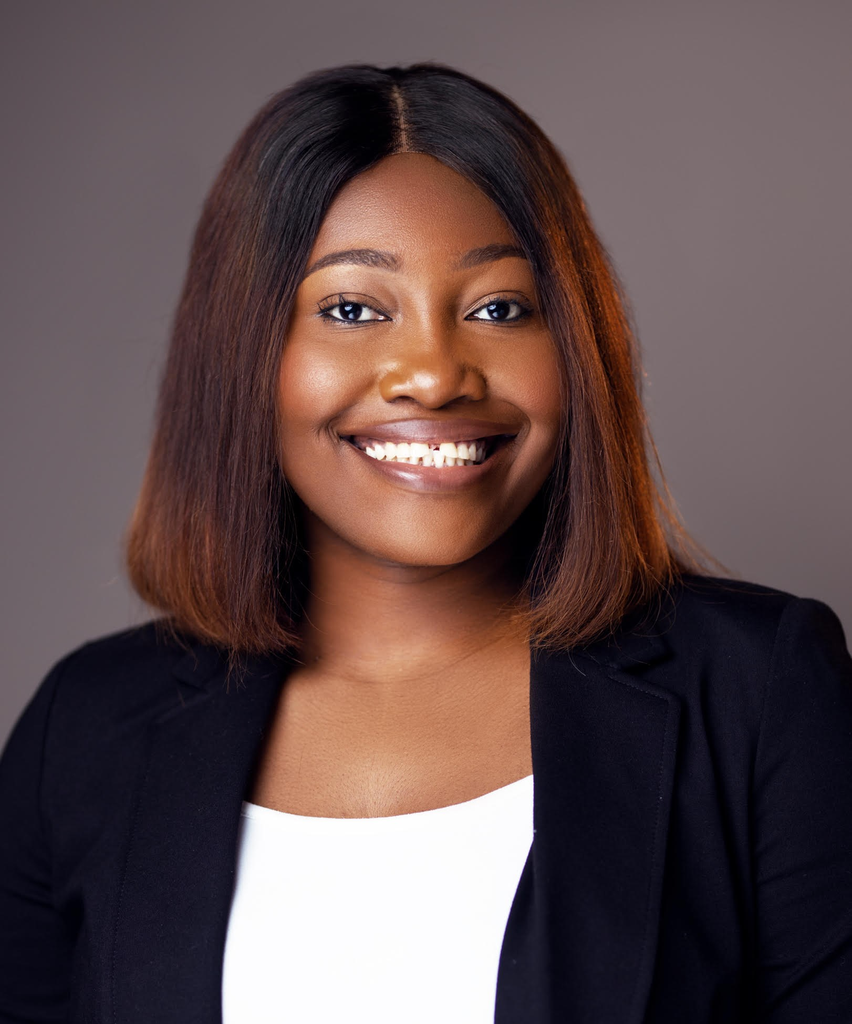

# Yaa Adoma Kwapong

## About Me

I am a physician and clinical researcher with a background in public health and cardiovascular research. My interests include women’s cardiovascular health, pregnancy-related cardiovascular conditions, and health disparities.

I have experience with statistics and clinical research, and very familiar with Stata but I am excited to become more confident using R. I am especially interested in data science and how it can be applied to clinical research, including electronic health record data and reproducible analysis.

Through this course, I hope to strengthen my programming skills and become more comfortable using R, Git, and GitHub in my research.

## Five Fun Facts

1. I completed my medical training in Ghana.
2. I am the first physician in my extended family.
3. I have lived in both the east and West coasts of the United states.
4. I love spending time with my family.
5. I am fascinated by how technology and data can improve health research.

## Something That Interests Me

I am especially interested in data science and precision medicine, and how clinical and electronic health record data can be used to answer meaningful questions and improve patient outcomes.